# final project

```r
library(caret)
library(randomForest)
```

```r
library(corrplot)
library(readr)
```

##load the data from coursera website

```r
Trainset <- read.csv("https://d396qusza40orc.cloudfront.net/predmachlearn/pml-training.csv")
Testset <- read.csv("https://d396qusza40orc.cloudfront.net/predmachlearn/pml-testing.csv")
```

##cleaning data ##remove NA from dataset ##Identify the parameter columns that are almost empty and remove them from dataset.

```r
nacol <- colSums(is.na(Trainset))<nrow(Trainset)*0.95
Trainset <- Trainset[,nacol==TRUE]
dim(Trainset)
```

```
## [1] 19622    93
```

##remove zero variance data ##Identify the parameters that are similar for every sample which have no reference value and remove them from dataset.

```r
nzv <- nearZeroVar(Trainset)
Trainset <- Trainset[,-nzv]
dim(Trainset)
```

```
## [1] 19622    59
```

##remove identification only variables ##Remove the parameters for identification and are not useful in this analysis from the dataset.

```r
Trainset<-Trainset[,-(1:6)]
dim(Trainset)
```

```
## [1] 19622    53
```

##splitting training set into two ##70% of the trainset is allocated to myTraining and 30% of it is allocated to myTesting ##As there are no “classe” column which is the result of prediction in the provided testing data set, it is necessary to split the training dataset into 2 parts to test the out of sample error of the prediction.

```r
set.seed(1221)
new_Train <- createDataPartition(Trainset$classe, p=0.7, list=FALSE)
myTraining <- Trainset[new_Train, ]
myTesting <- Trainset[-new_Train, ]

dim(myTraining)
```

```
## [1] 13737    53
```

```r
dim(myTesting)
```

```
## [1] 5885   53
```

##correlation analysis ##To avoid the bias coming from related or causal parameters, correlation analysis is implemented to test whether there exist parameters that are highly correlated to each other.

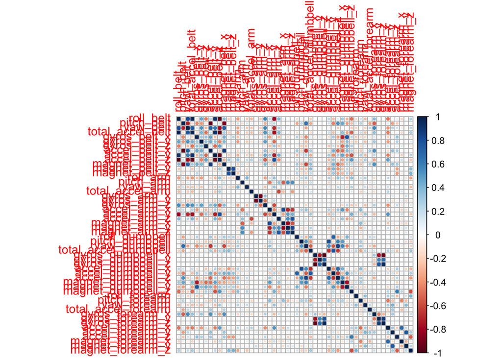

```r
corMatrix <- cor(myTraining[, -53])
corrplot(corMatrix)
```

##Prediction with models ##Prediction with classification trees

```r
set.seed(1221)
modfit_rpart<-train(classe~.,method="rpart",data=myTraining)
print(modfit_rpart)
```

```
## CART
##
## 13737 samples
##    52 predictor
##     5 classes: 'A', 'B', 'C', 'D', 'E'
##
## No pre-processing
## Resampling: Bootstrapped (25 reps)
## Summary of sample sizes: 13737, 13737, 13737, 13737, 13737, 13737, ...
## Resampling results across tuning parameters:
##
##   cp          Accuracy   Kappa
##   0.03580511  0.5114545  0.36353290
##   0.06116706  0.4172466  0.20996184
##   0.11260299  0.3256381  0.06265359
##
## Accuracy was used to select the optimal model using the largest value.
## The final value used for the model was cp = 0.03580511.
```

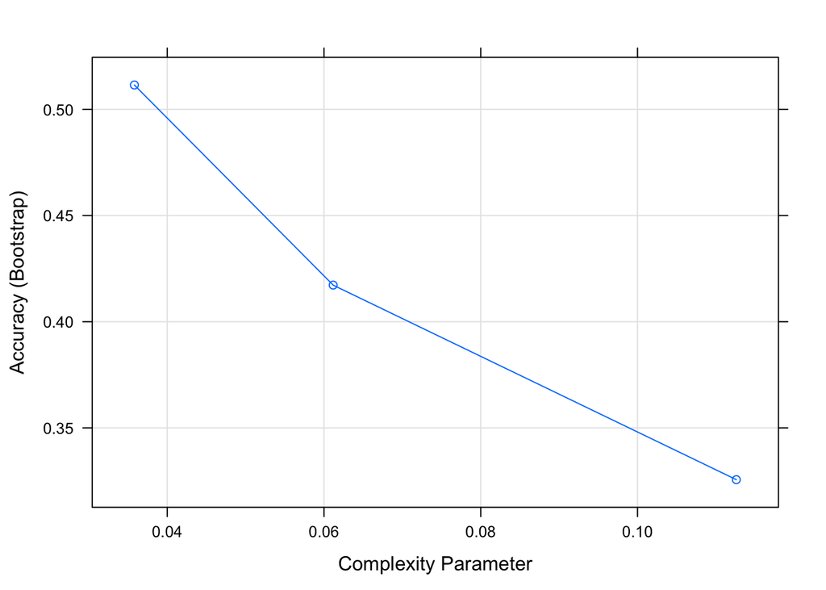

```r
plot(modfit_rpart)
```

##from the output, the accuracy of classification tree is 0.4933, thus the out-of-sample error is 0.5067

```r
predict_rpart <- predict(modfit_rpart, newdata=myTesting)
cm_rpart <- confusionMatrix(predict_rpart, myTesting$classe)
print(cm_rpart)
```

```
## Confusion Matrix and Statistics
##
##           Reference
## Prediction    A    B    C    D    E
##          A 1498  458  485  429  143
##          B   24  386   40  166  146
##          C  144  295  501  369  275
##          D    0    0    0    0    0
##          E    8    0    0    0  518
##
## Overall Statistics
##
##                Accuracy : 0.4933
##                  95% CI : (0.4804, 0.5061)
##     No Information Rate : 0.2845
##     P-Value [Acc > NIR] : < 2.2e-16
##
##                   Kappa : 0.3385
##
##  Mcnemar's Test P-Value : NA
##
## Statistics by Class:
##
##                      Class: A Class: B Class: C Class: D Class: E
## Sensitivity            0.8949  0.33889  0.48830   0.0000  0.47874
## Specificity            0.6402  0.92078  0.77711   1.0000  0.99833
## Pos Pred Value         0.4972  0.50656  0.31629      NaN  0.98479
## Neg Pred Value         0.9387  0.85302  0.87794   0.8362  0.89476
## Prevalence             0.2845  0.19354  0.17434   0.1638  0.18386
## Detection Rate         0.2545  0.06559  0.08513   0.0000  0.08802
## Detection Prevalence   0.5120  0.12948  0.26916   0.0000  0.08938
## Balanced Accuracy      0.7675  0.62983  0.63271   0.5000  0.73854
```

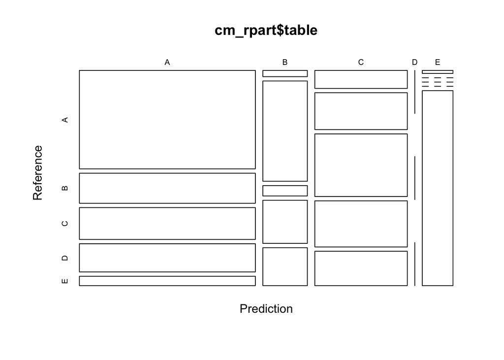

```r
plot(cm_rpart$table,col = cm_rpart$byClass)
```

##Prediction with Random Forest

```r
set.seed(1221)
modfit_RF <- train(classe~., method="rf",data=myTraining, trcontrol=trainControl(method="cv"),number=3)
print(modfit_RF)
```

```
## Random Forest
##
## 13737 samples
##    52 predictor
##     5 classes: 'A', 'B', 'C', 'D', 'E'
##
## No pre-processing
## Resampling: Bootstrapped (25 reps)
## Summary of sample sizes: 13737, 13737, 13737, 13737, 13737, 13737, ...
## Resampling results across tuning parameters:
##
##   mtry  Accuracy   Kappa
##    2    0.9878696  0.9846519
##   27    0.9877285  0.9844737
##   52    0.9786243  0.9729527
##
## Accuracy was used to select the optimal model using the largest value.
## The final value used for the model was mtry = 2.
```

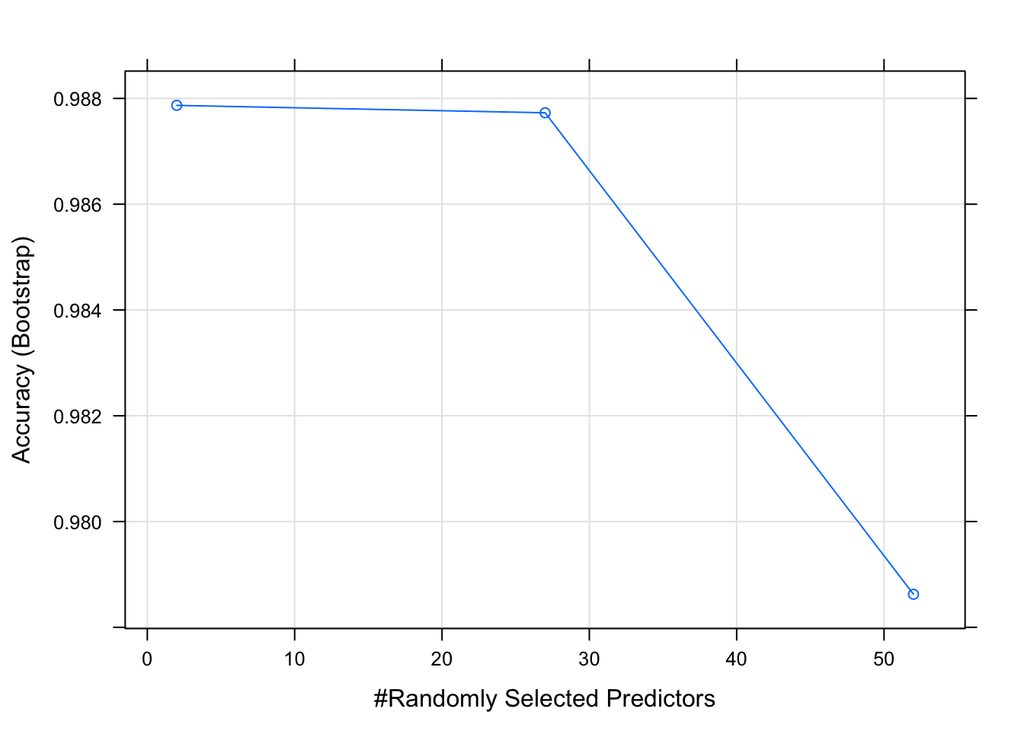

```r
plot(modfit_RF)
```

##from the output, the accuracy of RF is 0.992, thus the out-of-sample error is 0.008

```r
predict_RF<- predict(modfit_RF, newdata=myTesting)
cm_RF <- confusionMatrix(predict_RF, myTesting$classe)
print(cm_RF)
```

```
## Confusion Matrix and Statistics
##
##           Reference
## Prediction    A    B    C    D    E
##          A 1673    4    0    0    0
##          B    1 1135   14    0    0
##          C    0    0 1010   21    1
##          D    0    0    2  942    3
##          E    0    0    0    1 1078
##
## Overall Statistics
##
##                Accuracy : 0.992
##                  95% CI : (0.9894, 0.9941)
##     No Information Rate : 0.2845
##     P-Value [Acc > NIR] : < 2.2e-16
##
##                   Kappa : 0.9899
##
##  Mcnemar's Test P-Value : NA
##
## Statistics by Class:
##
##                      Class: A Class: B Class: C Class: D Class: E
## Sensitivity            0.9994   0.9965   0.9844   0.9772   0.9963
## Specificity            0.9991   0.9968   0.9955   0.9990   0.9998
## Pos Pred Value         0.9976   0.9870   0.9787   0.9947   0.9991
## Neg Pred Value         0.9998   0.9992   0.9967   0.9955   0.9992
## Prevalence             0.2845   0.1935   0.1743   0.1638   0.1839
## Detection Rate         0.2843   0.1929   0.1716   0.1601   0.1832
## Detection Prevalence   0.2850   0.1954   0.1754   0.1609   0.1833
## Balanced Accuracy      0.9992   0.9967   0.9899   0.9881   0.9980
```

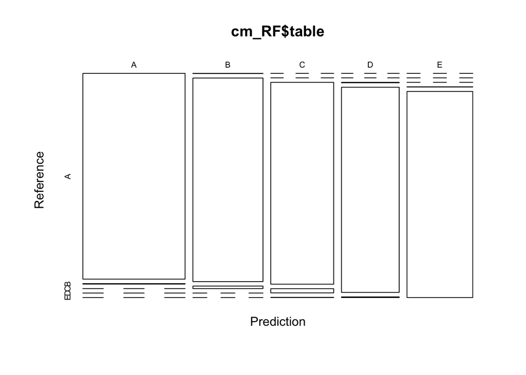

```r
plot(cm_RF$table,col = cm_RF$byClass)
```

##Comparing the accuracy, RF model is quite sarisfying while Classification tree is not, there is no point of combine these two

##Prediction of the testing set based on RF model

```r
predict_testset<- predict(modfit_RF, newdata=Testset)
predict_testset
```

```
##  [1] B A B A A E D B A A B C B A E E A B B B
## Levels: A B C D E
```